# Homework 10

Homework 10 Maria Alfaro 3/30/2022

Home Page

#### 1. Using a for loop, write a function to calculate the number of zeroes in a numeric vector. Before entering the loop, set up a counter variable counter <- 0. Inside the loop, add 1 to counter each time you have a zero in the vector. Finally, use return(counter) for the output.

```r
counter = 0
pre_vec = runif(0:100)
my_vec = ifelse(pre_vec>0.5,1,0)
print(my_vec)
```

```
##   [1] 1 1 1 1 1 0 0 1 1 1 1 1 1 0 0 0 0 0 0 0 0 0 1 1 1 0 0 0 0 0 1 1 1 0 0 1 1
##  [38] 1 1 0 1 0 0 0 1 1 0 0 1 1 1 0 0 0 1 1 0 1 0 0 1 0 1 0 0 0 1 0 1 0 1 0 1 0
##  [75] 1 0 0 0 1 1 0 0 0 1 0 0 1 0 1 0 1 0 1 1 1 1 0 0 0 1 1
```

```r
count_myvec = function(counter=0){
  for(i in 1:length(my_vec)){
  if(my_vec[i]==0){
    counter = counter + 1
  }
  }
  return(counter)
}
count_myvec()
```

```
## [1] 52
```

#### 2. Use subsetting instead of a loop to rewrite the function as a single line of code.

```r
count_myvec2 = function(counter=0){
  length(my_vec[my_vec == 0])
}
count_myvec2()
```

```
## [1] 52
```

#### 3. Write a function that takes as input two integers representing the number of rows and columns in a matrix. The output is a matrix of these dimensions in which each element is the product of the row number x the column number.

```r
timestable = function(x=9,y=10){
  makeTT = matrix(nrow=y,ncol=x)
  for(i in 1:nrow(makeTT)){
    for(j in 1:ncol(makeTT)){
      makeTT[i,j] = i*j
    }
  }
return(makeTT)
}
ninebyten = timestable()
print(ninebyten)
```

```
##       [,1] [,2] [,3] [,4] [,5] [,6] [,7] [,8] [,9]
##  [1,]    1    2    3    4    5    6    7    8    9
##  [2,]    2    4    6    8   10   12   14   16   18
##  [3,]    3    6    9   12   15   18   21   24   27
##  [4,]    4    8   12   16   20   24   28   32   36
##  [5,]    5   10   15   20   25   30   35   40   45
##  [6,]    6   12   18   24   30   36   42   48   54
##  [7,]    7   14   21   28   35   42   49   56   63
##  [8,]    8   16   24   32   40   48   56   64   72
##  [9,]    9   18   27   36   45   54   63   72   81
## [10,]   10   20   30   40   50   60   70   80   90
```

#### 4. In the next few lectures, you will learn how to do a randomization test on your data. We will complete some of the steps today to practice calling custom functions within a for loop. Use the code from the March 31st lecture (Randomization Tests) to complete the following steps:

##### a. Simulate a dataset with 3 groups of data, each group drawn from a distribution with a different mean. The final data frame should have 1 column for group and 1 column for the response variable.

```r
group1 = rnorm(n=20,mean=5,sd=0.1)
group2 = rnorm(n=20,mean=10,sd=0.1)
group3 = rnorm(n=20,mean=15,sd=0.1)

group = c(rep("group1",20),rep("group2",20),rep("group3",20))
response = c(group1,group2,group3)

my_df = data.frame(group,response)

print(my_df)
```

```
##     group  response
## 1  group1  4.917592
## 2  group1  5.148940
## 3  group1  4.911602
## 4  group1  4.936133
## 5  group1  5.031800
## 6  group1  5.016486
## 7  group1  4.893159
## 8  group1  5.039505
## 9  group1  5.048681
## 10 group1  5.134871
## 11 group1  4.931540
## 12 group1  4.891423
## 13 group1  5.058913
## 14 group1  4.983532
```

[output cut: 46 more lines]

##### b. Write a custom function that 1) reshuffles the response variable, and 2) calculates the mean of each group in the reshuffled data. Store the means in a vector of length 3.

```r
library(dplyr)
shuffle_calcmeans = function(df=my_df){
  shuff_resp = sample(df$response)
  shuff_df = data.frame(group,shuff_resp)
  group_means = aggregate(shuff_df$shuff_resp,list(shuff_df$group),FUN=mean)
  vec_means = group_means$x

  return(vec_means)
}

shuff_means = shuffle_calcmeans()
print(shuff_means)
```

```
## [1] 10.276991  9.257257 10.490310
```

##### c. Use a for loop to repeat the function in b 100 times. Store the results in a data frame that has 1 column indicating the replicate number and 1 column for each new group mean, for a total of 4 columns.

```r
hun_shuff_df = data.frame(replicate=NA,group1_mean=NA,group2_mean=NA,group3_mean=NA)

for(i in 1:100){
  hun_shuff_df[i,] = c(i,shuffle_calcmeans())
}
print(hun_shuff_df)
```

```
##     replicate group1_mean group2_mean group3_mean
## 1           1   10.777158    9.499201    9.748198
## 2           2   10.008137    9.257162   10.759259
## 3           3    9.256905   10.257508   10.510144
## 4           4    9.252882   11.275017    9.496660
## 5           5   10.022146    9.769780   10.232632
## 6           6   10.511696    8.757700   10.755162
## 7           7   10.747908    9.757068    9.519581
## 8           8    9.731820   10.539387    9.753351
## 9           9   10.972761    9.015553   10.036245
## 10         10   10.772353    8.757419   10.494785
## 11         11   10.255411    9.736462   10.032685
## 12         12   10.514819    9.262364   10.247375
## 13         13    8.769344   11.011461   10.243753
## 14         14    9.983617   11.285327    8.755614
```

[output cut: 86 more lines]

##### d. Use qplot() to create a histogram of the means for each reshuffled group. Or, if you want a challenge, use ggplot() to overlay all 3 histograms in the same figure. How do the distributions of reshuffled means compare to the original means?

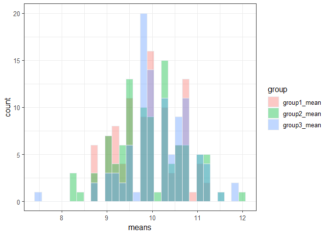

```r
library(ggplot2)
library(tidyr)

final_df = pivot_longer(hun_shuff_df,c("group1_mean","group2_mean","group3_mean"),names_to="group",values_to="means")
final_df = select(final_df,-"replicate")

hun_shuff_plot = ggplot(final_df,aes(x=means,fill=group)) +
  theme_bw(12) +
  geom_histogram(color='#e9ecef',alpha=0.4,position='identity',bins=30)


hun_shuff_plot
```

The reshuffled means are all around 10, whereas the original means were more distinctly different (5,10,15).